# Deep Learning_un proctored-Question

## PART B 10 MARKS- ANSWERS FOR ALL THE QUESTIONS

### Multi Class Classification

**Dataset Description**

Hello all,

The attached dataset (named "Dataset") contains three folders:

- train (60 images each)
- test (7 images each)
- validation (7 images each) each of the above folders contains subfolders for different fruits and vegetables wherein the images for respective food items are present

This dataset contains images of the following food items:

- **fruits**: banana, apple, pear, grapes, orange, kiwi, watermelon, pomegranate, pineapple, mango
- **vegetables**: cucumber, carrot, capsicum, onion, potato, lemon, tomato, raddish, beetroot, cabbage, lettuce, spinach, soy bean, cauliflower, bell pepper

NOTE: Dataset acquired from the internet and entire credit goes to the original author

**A Dataframe consisting of file paths and corresponding labels has already been created for test, train and validation datasets.**

**Task Description**

- Build a Multi-class classification Model.

**INSTRUCTIONS:**

- Your code should be unique and give some possible explanation of the architecture.
- Incase of similarities between two peers submissions, The submissions will be considered as copy and plagirazied and marks will be ZERO.
- Feel free to explore different approaches (within Deep Learning).
- Duration is 60 minutes. Late submission will not be allowed at any cost.

All the best.

```python
import numpy as np
import pandas as pd
from pathlib import Path
import os.path
import matplotlib.pyplot as plt
import tensorflow as tf
import glob
from sklearn.metrics import accuracy_score
from sklearn.metrics import confusion_matrix
import seaborn as sns
from tensorflow.keras.preprocessing.image import ImageDataGenerator
from tensorflow.keras.applications import MobileNetV2

train_file_list=[]
test_file_list=[]
val_file_list=[]

for filename in glob.iglob('Dataset/train/**/*.jpg',
                           recursive = True):
    filename = filename.replace("\\", "/")
    train_file_list.append(filename)

for filename in glob.iglob('Dataset/test/**/*.jpg',
                           recursive = True):
    filename = filename.replace("\\", "/")
    test_file_list.append(filename)

for filename in glob.iglob('Dataset/validation/**/*.jpg',
                           recursive = True):
    filename = filename.replace("\\", "/")
    val_file_list.append(filename)


def proc_img(filepath):
    """ Create a DataFrame with the filepath and the labels of the pictures
    """

    labels = [str(filepath[i]).split("/")[-2] \
              for i in range(len(filepath))]

    filepath = pd.Series(filepath, name='Filepath').astype(str)
    labels = pd.Series(labels, name='Label')

    # Concatenate filepaths and labels
    df = pd.concat([filepath, labels], axis=1)

    # Shuffle the DataFrame and reset index
    df = df.sample(frac=1).reset_index(drop = True)

    return df

#A Dataframe consisting of file paths and corresponding labels has already been created for test, train and validation datasets.
train_df = proc_img(train_file_list)
test_df = proc_img(test_file_list)
val_df = proc_img(val_file_list)
```

### Expected Sub-tasks

- Loading and Pre-Processing (2.5 Marks)
- Data Augmentation (2.5 Marks)
- Model Training (2.5 Marks)
- Evaluation of the trained Model and Visualisations of the result (2.5 Marks)

```python
import tensorflow as tf
import os

# Set dataset directory path
dataset_dir = "Dataset"

# Define paths
train_dir = os.path.join(dataset_dir, "train")
val_dir   = os.path.join(dataset_dir, "validation")
test_dir  = os.path.join(dataset_dir, "test")

# Parameters
img_height = 224
img_width = 224
batch_size = 32
```

```python
# Load datasets
train_ds = tf.keras.utils.image_dataset_from_directory(
    train_dir,
    image_size=(img_height, img_width),
    batch_size=batch_size
)

val_ds = tf.keras.utils.image_dataset_from_directory(
    val_dir,
    image_size=(img_height, img_width),
    batch_size=batch_size
)

test_ds = tf.keras.utils.image_dataset_from_directory(
    test_dir,
    image_size=(img_height, img_width),
    batch_size=batch_size
)
```

```
Found 1500 files belonging to 25 classes.
Found 175 files belonging to 25 classes.
Found 175 files belonging to 25 classes.
```

```python
class_names = train_ds.class_names
print("Classes:", class_names)

# Optimize performance (after extracting class_names)
AUTOTUNE = tf.data.AUTOTUNE

train_ds = train_ds.cache().shuffle(1000).prefetch(buffer_size=AUTOTUNE)
val_ds   = val_ds.cache().prefetch(buffer_size=AUTOTUNE)
test_ds  = test_ds.cache().prefetch(buffer_size=AUTOTUNE)
```

```
Classes: ['apple', 'banana', 'beetroot', 'bell pepper', 'cabbage', 'capsicum', 'carrot', 'cauliflower', 'cucumber', 'grapes', 'kiwi', 'lemon', 'lettuce', 'mango', 'onion', 'orange', 'pear', 'pineapple', 'pomegranate', 'potato', 'raddish', 'soy beans', 'spinach', 'tomato', 'watermelon']
```

```python
for images, labels in train_ds.take(1):
    print(images.shape)
    print(labels.numpy())
```

```
(32, 224, 224, 3)
[20  3 10 14  1  1 22  8 24  0 20 13 16 12 15  3 11 10 19 20 14 11  3  2
  1  8 20 21 12 20 21 20]
```

```python
normalization_layer = tf.keras.layers.Rescaling(1./255)
train_ds = train_ds.map(lambda x, y: (normalization_layer(x), y))
val_ds   = val_ds.map(lambda x, y: (normalization_layer(x), y))
test_ds  = test_ds.map(lambda x, y: (normalization_layer(x), y))
```

```python
data_augmentation = tf.keras.Sequential([
    tf.keras.layers.RandomFlip("horizontal"),
    tf.keras.layers.RandomRotation(0.1),
    tf.keras.layers.RandomZoom(0.1),
])
```

```python
train_ds = train_ds.map(lambda x, y: (data_augmentation(x, training=True), y))
```

```python
from tensorflow import keras
from tensorflow.keras import layers
```

```python
num_classes = len(class_names)
```

```python
# ------------------------------
# Build CNN Model
# ------------------------------
model = keras.Sequential([
    layers.InputLayer(shape=(img_height, img_width, 3)),

    data_augmentation,           # apply augmentation
    normalization_layer,         # normalize pixel values

    layers.Conv2D(32, (3,3), activation='relu'),
    layers.MaxPooling2D(),

    layers.Conv2D(64, (3,3), activation='relu'),
    layers.MaxPooling2D(),

    layers.Conv2D(128, (3,3), activation='relu'),
    layers.MaxPooling2D(),

    layers.Flatten(),
    layers.Dense(128, activation='relu'),
    layers.Dropout(0.5),         # prevent overfitting
    layers.Dense(num_classes, activation='softmax')  # output layer
])
```

```python
# ------------------------------
# Compile Model
# ------------------------------
model.compile(
    optimizer='adam',
    loss='sparse_categorical_crossentropy',
    metrics=['accuracy']
)
```

```python
# ------------------------------
# Train Model
# ------------------------------
epochs = 15
history = model.fit(
    train_ds,
    validation_data=val_ds,
    epochs=epochs
)
```

```
47/47 ━━━━━━━━━━━━━━━━━━━━ 27s 545ms/step - accuracy: 0.0387 - loss: 3.2209 - val_accuracy: 0.0400 - val_loss: 3.2189
47/47 ━━━━━━━━━━━━━━━━━━━━ 25s 519ms/step - accuracy: 0.0320 - loss: 3.2194 - val_accuracy: 0.0400 - val_loss: 3.2189
47/47 ━━━━━━━━━━━━━━━━━━━━ 25s 517ms/step - accuracy: 0.0387 - loss: 3.2193 - val_accuracy: 0.0400 - val_loss: 3.2189
47/47 ━━━━━━━━━━━━━━━━━━━━ 25s 515ms/step - accuracy: 0.0447 - loss: 3.2194 - val_accuracy: 0.0400 - val_loss: 3.2189
47/47 ━━━━━━━━━━━━━━━━━━━━ 24s 514ms/step - accuracy: 0.0293 - loss: 3.2196 - val_accuracy: 0.0400 - val_loss: 3.2189
47/47 ━━━━━━━━━━━━━━━━━━━━ 25s 515ms/step - accuracy: 0.0253 - loss: 3.2192 - val_accuracy: 0.0400 - val_loss: 3.2189
47/47 ━━━━━━━━━━━━━━━━━━━━ 25s 526ms/step - accuracy: 0.0420 - loss: 3.2192 - val_accuracy: 0.0400 - val_loss: 3.2189
47/47 ━━━━━━━━━━━━━━━━━━━━ 25s 535ms/step - accuracy: 0.0340 - loss: 3.2194 - val_accuracy: 0.0400 - val_loss: 3.2189
47/47 ━━━━━━━━━━━━━━━━━━━━ 26s 551ms/step - accuracy: 0.0360 - loss: 3.2193 - val_accuracy: 0.0400 - val_loss: 3.2189
47/47 ━━━━━━━━━━━━━━━━━━━━ 27s 569ms/step - accuracy: 0.0327 - loss: 3.2191 - val_accuracy: 0.0400 - val_loss: 3.2189
47/47 ━━━━━━━━━━━━━━━━━━━━ 27s 566ms/step - accuracy: 0.0360 - loss: 3.2193 - val_accuracy: 0.0400 - val_loss: 3.2189
47/47 ━━━━━━━━━━━━━━━━━━━━ 26s 549ms/step - accuracy: 0.0307 - loss: 3.2192 - val_accuracy: 0.0400 - val_loss: 3.2189
47/47 ━━━━━━━━━━━━━━━━━━━━ 26s 546ms/step - accuracy: 0.0333 - loss: 3.2192 - val_accuracy: 0.0400 - val_loss: 3.2189
47/47 ━━━━━━━━━━━━━━━━━━━━ 27s 562ms/step - accuracy: 0.0347 - loss: 3.2193 - val_accuracy: 0.0400 - val_loss: 3.2189
47/47 ━━━━━━━━━━━━━━━━━━━━ 27s 575ms/step - accuracy: 0.0327 - loss: 3.2192 - val_accuracy: 0.0400 - val_loss: 3.2189
```

```python
# ------------------------------
# Evaluate on Test Data
# ------------------------------
test_loss, test_acc = model.evaluate(test_ds)
print(f"\nTest Accuracy: {test_acc:.4f}")
```

```
6/6 ━━━━━━━━━━━━━━━━━━━━ 1s 201ms/step - accuracy: 0.0400 - loss: 3.2189

✅ Test Accuracy: 0.0400
```

```python
print("Number of classes:", len(class_names))
for i, class_name in enumerate(class_names):
    print(i, class_name)
```

```
Number of classes: 25
0 apple
1 banana
2 beetroot
3 bell pepper
4 cabbage
5 capsicum
6 carrot
7 cauliflower
8 cucumber
9 grapes
10 kiwi
11 lemon
12 lettuce
13 mango
14 onion
15 orange
16 pear
17 pineapple
18 pomegranate
19 potato
20 raddish
21 soy beans
22 spinach
23 tomato
24 watermelon
```

```python
base_model = tf.keras.applications.MobileNetV2(
    input_shape=(224,224,3),
    include_top=False,
    weights='imagenet'
)
base_model.trainable = False  # freeze base model

model = keras.Sequential([
    data_augmentation,
    layers.Rescaling(1./255),
    base_model,
    layers.GlobalAveragePooling2D(),
    layers.Dense(128, activation='relu'),
    layers.Dropout(0.5),
    layers.Dense(num_classes, activation='softmax')
])
```

```
Downloading data from https://storage.googleapis.com/tensorflow/keras-applications/mobilenet_v2/mobilenet_v2_weights_tf_dim_ordering_tf_kernels_1.0_224_no_top.h5
9406464/9406464 ━━━━━━━━━━━━━━━━━━━━ 1s 0us/step
```

```python
# ------------------------------
# Build Transfer Learning Model
# ------------------------------
base_model = tf.keras.applications.MobileNetV2(
    input_shape=(224, 224, 3),
    include_top=False,       # remove final classification head
    weights='imagenet'       # use pretrained weights
)
base_model.trainable = False  # freeze base model for now

model = keras.Sequential([
    data_augmentation,           # from earlier
    layers.Rescaling(1./255),
    base_model,
    layers.GlobalAveragePooling2D(),
    layers.Dense(128, activation='relu'),
    layers.Dropout(0.5),
    layers.Dense(num_classes, activation='softmax')  # output layer
])

# ------------------------------
# Compile
# ------------------------------
model.compile(
    optimizer='adam',
    loss='sparse_categorical_crossentropy',
    metrics=['accuracy']
)

# ------------------------------
# Train (initial training with frozen base)
# ------------------------------
epochs = 10
history = model.fit(
    train_ds,
    validation_data=val_ds,
    epochs=epochs
)

# ------------------------------
# Evaluate on Test Data
# ------------------------------
test_loss, test_acc = model.evaluate(test_ds)
print(f"\nTest Accuracy: {test_acc:.4f}")
```

```
47/47 ━━━━━━━━━━━━━━━━━━━━ 29s 546ms/step - accuracy: 0.0360 - loss: 3.2694 - val_accuracy: 0.0400 - val_loss: 3.2189
47/47 ━━━━━━━━━━━━━━━━━━━━ 25s 526ms/step - accuracy: 0.0360 - loss: 3.2192 - val_accuracy: 0.0400 - val_loss: 3.2189
47/47 ━━━━━━━━━━━━━━━━━━━━ 25s 530ms/step - accuracy: 0.0340 - loss: 3.2228 - val_accuracy: 0.0400 - val_loss: 3.2189
47/47 ━━━━━━━━━━━━━━━━━━━━ 25s 533ms/step - accuracy: 0.0360 - loss: 3.2192 - val_accuracy: 0.0400 - val_loss: 3.2189
47/47 ━━━━━━━━━━━━━━━━━━━━ 25s 533ms/step - accuracy: 0.0387 - loss: 3.2192 - val_accuracy: 0.0400 - val_loss: 3.2189
47/47 ━━━━━━━━━━━━━━━━━━━━ 25s 530ms/step - accuracy: 0.0353 - loss: 3.2192 - val_accuracy: 0.0400 - val_loss: 3.2189
47/47 ━━━━━━━━━━━━━━━━━━━━ 26s 540ms/step - accuracy: 0.0400 - loss: 3.2192 - val_accuracy: 0.0400 - val_loss: 3.2189
47/47 ━━━━━━━━━━━━━━━━━━━━ 26s 552ms/step - accuracy: 0.0333 - loss: 3.2192 - val_accuracy: 0.0400 - val_loss: 3.2189
47/47 ━━━━━━━━━━━━━━━━━━━━ 27s 567ms/step - accuracy: 0.0280 - loss: 3.2192 - val_accuracy: 0.0400 - val_loss: 3.2189
47/47 ━━━━━━━━━━━━━━━━━━━━ 27s 568ms/step - accuracy: 0.0320 - loss: 3.2191 - val_accuracy: 0.0400 - val_loss: 3.2189
6/6 ━━━━━━━━━━━━━━━━━━━━ 2s 392ms/step - accuracy: 0.0400 - loss: 3.2189

✅ Test Accuracy: 0.0400
```

```python
import os
for cls in class_names:
    print(cls, ":", len(os.listdir(os.path.join("dataset/train", cls))))
```

```
apple : 60
banana : 60
beetroot : 60
bell pepper : 60
cabbage : 60
capsicum : 60
carrot : 60
cauliflower : 60
cucumber : 60
grapes : 60
kiwi : 60
lemon : 60
lettuce : 60
mango : 60
onion : 60
orange : 60
pear : 60
pineapple : 60
pomegranate : 60
potato : 60
raddish : 60
soy beans : 60
spinach : 60
tomato : 60
watermelon : 60
```

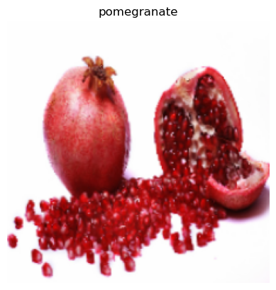

```python
for images, labels in train_ds.take(1):
    plt.imshow(images[0])   # no need for astype("uint8")
    plt.title(class_names[labels[0]])
    plt.axis("off")   # optional, cleaner display
    plt.show()
```

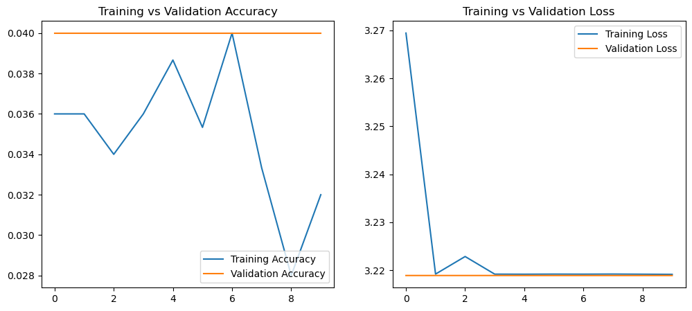

```python
acc = history.history['accuracy']
val_acc = history.history['val_accuracy']
loss = history.history['loss']
val_loss = history.history['val_loss']

epochs_range = range(epochs)

plt.figure(figsize=(12, 5))

# Accuracy
plt.subplot(1, 2, 1)
plt.plot(epochs_range, acc, label='Training Accuracy')
plt.plot(epochs_range, val_acc, label='Validation Accuracy')
plt.legend(loc='lower right')
plt.title('Training vs Validation Accuracy')

# Loss
plt.subplot(1, 2, 2)
plt.plot(epochs_range, loss, label='Training Loss')
plt.plot(epochs_range, val_loss, label='Validation Loss')
plt.legend(loc='upper right')
plt.title('Training vs Validation Loss')

plt.show()
```

```python
base_model.trainable = True
model.compile(optimizer=tf.keras.optimizers.Adam(1e-5),   # smaller LR
              loss='sparse_categorical_crossentropy',
              metrics=['accuracy'])
epochs = 10
history = model.fit(
    train_ds,
    validation_data=val_ds,
    epochs=epochs
)
test_loss, test_acc = model.evaluate(test_ds)
print(f"\nTest Accuracy: {test_acc:.4f}")
```

```
47/47 ━━━━━━━━━━━━━━━━━━━━ 139s 3s/step - accuracy: 0.0320 - loss: 3.3578 - val_accuracy: 0.0400 - val_loss: 3.2194
47/47 ━━━━━━━━━━━━━━━━━━━━ 118s 3s/step - accuracy: 0.0607 - loss: 3.2567 - val_accuracy: 0.0400 - val_loss: 3.2206
47/47 ━━━━━━━━━━━━━━━━━━━━ 121s 3s/step - accuracy: 0.0740 - loss: 3.1559 - val_accuracy: 0.0400 - val_loss: 3.2250
47/47 ━━━━━━━━━━━━━━━━━━━━ 120s 3s/step - accuracy: 0.1113 - loss: 3.0681 - val_accuracy: 0.0400 - val_loss: 3.2296
47/47 ━━━━━━━━━━━━━━━━━━━━ 119s 3s/step - accuracy: 0.1320 - loss: 2.9878 - val_accuracy: 0.0400 - val_loss: 3.2331
47/47 ━━━━━━━━━━━━━━━━━━━━ 119s 3s/step - accuracy: 0.1853 - loss: 2.8723 - val_accuracy: 0.0400 - val_loss: 3.2362
47/47 ━━━━━━━━━━━━━━━━━━━━ 122s 3s/step - accuracy: 0.1973 - loss: 2.8172 - val_accuracy: 0.0400 - val_loss: 3.2509
47/47 ━━━━━━━━━━━━━━━━━━━━ 119s 3s/step - accuracy: 0.2327 - loss: 2.7176 - val_accuracy: 0.0400 - val_loss: 3.2647
47/47 ━━━━━━━━━━━━━━━━━━━━ 121s 3s/step - accuracy: 0.2733 - loss: 2.6049 - val_accuracy: 0.0400 - val_loss: 3.2808
47/47 ━━━━━━━━━━━━━━━━━━━━ 123s 3s/step - accuracy: 0.2973 - loss: 2.5233 - val_accuracy: 0.0400 - val_loss: 3.2927
6/6 ━━━━━━━━━━━━━━━━━━━━ 3s 406ms/step - accuracy: 0.0400 - loss: 3.2928

Test Accuracy: 0.0400
```

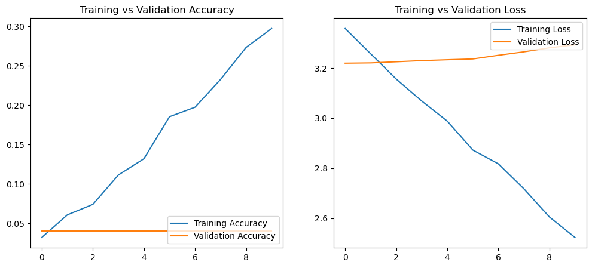

```python
acc = history.history['accuracy']
val_acc = history.history['val_accuracy']
loss = history.history['loss']
val_loss = history.history['val_loss']

epochs_range = range(epochs)

plt.figure(figsize=(12, 5))

# Accuracy
plt.subplot(1, 2, 1)
plt.plot(epochs_range, acc, label='Training Accuracy')
plt.plot(epochs_range, val_acc, label='Validation Accuracy')
plt.legend(loc='lower right')
plt.title('Training vs Validation Accuracy')

# Loss
plt.subplot(1, 2, 2)
plt.plot(epochs_range, loss, label='Training Loss')
plt.plot(epochs_range, val_loss, label='Validation Loss')
plt.legend(loc='upper right')
plt.title('Training vs Validation Loss')

plt.show()
```